# Lifting and training data analysis

[figure not shown]

[figure not shown]

[figure not shown]

[figure not shown]

[figure not shown]

[figure not shown]

[figure not shown]

[figure not shown]

# Lifts

#### Bench, Squat, Deadlift

- Data to come … (It takes a while to transcribe from my notebook). Goes back to ~2016-ish.

#### July 2019, hypertrophy

Training program:

Day 1:

- Low bar back squat (6x4)
- Conventional rack pulls (10x4)
- Leg press (15-20x4)
- Barbell front foot elevated front squat (10x4)
- Back extension (20x4)

Day 2:

- Barbell bench press (6x4)
- Wide grip pull ups (10x4)
- Single standing dumbell press (15-20x4)
- Single dumbell row (10x4)
- Bent over dumbell lateral raise (20x4)

Day 3:

- Conventional deadlift (6x4)
- Goblet squats (10x4)
- Single leg curl (15-20x4)
- Dumbell romanian deadlift (10x4)
- Dumbell walking lunge (15x4)

#### August 2019, hypertrophy

Training program:

Day 1:

- Low bar back squat (6x4)
- Conventional rack pulls (10x4)
- Leg press (15-20x4)
- Barbell front foot elevated front squat (10x4)
- Back extension (20x4)

Day 2:

- Barbell bench press (6x4)
- Wide grip pull ups (10x4)
- Single standing dumbell press (15-20x4)
- Single dumbell row (10x4)
- Bent over dumbell lateral raise (20x4)

Day 3:

- Conventional deadlift (6x4)
- Goblet squats (10x4)
- Single leg curl (15-20x4)
- Dumbell romanian deadlift (10x4)
- Dumbell walking lunge (15x4)

#### Bench, Squat, Deadlift

[figure not shown]

#### July 2019 data and graphs

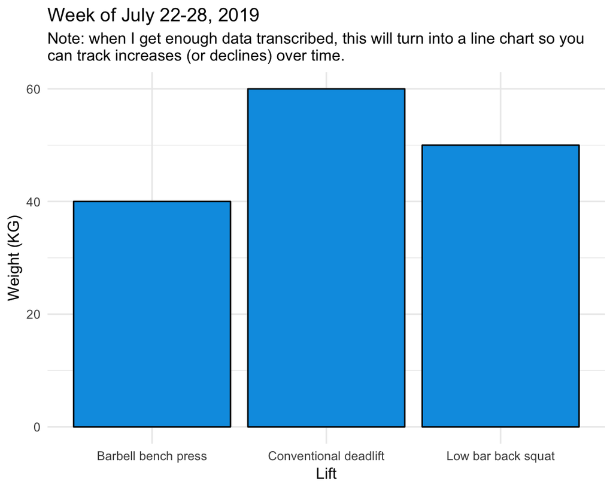

[figure not shown]

# Weight

### Weight, daily

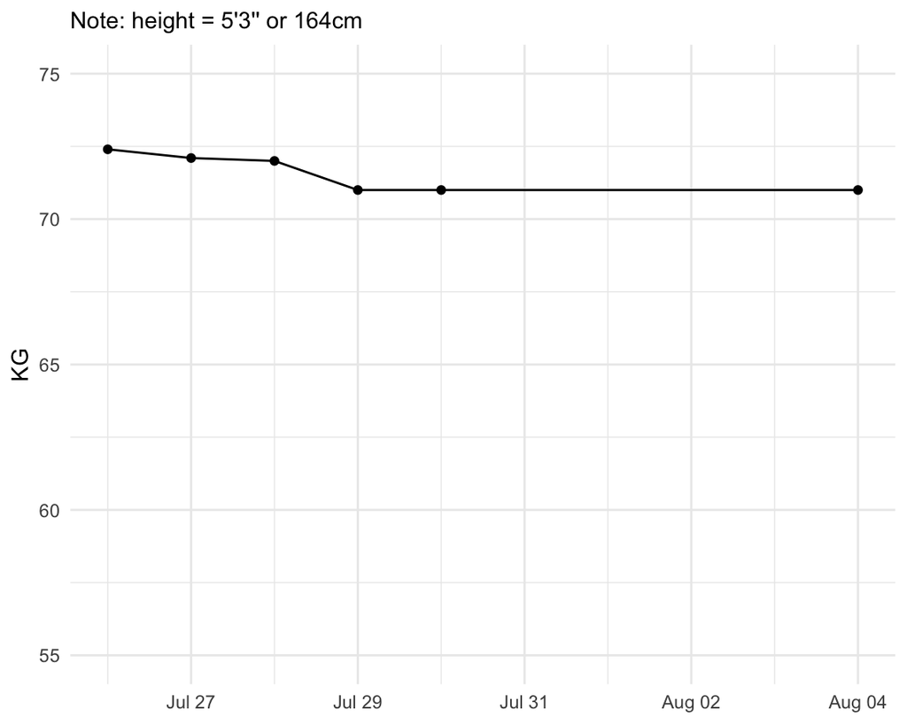

# Food Tracking

#### Daily tracking of macronutrients

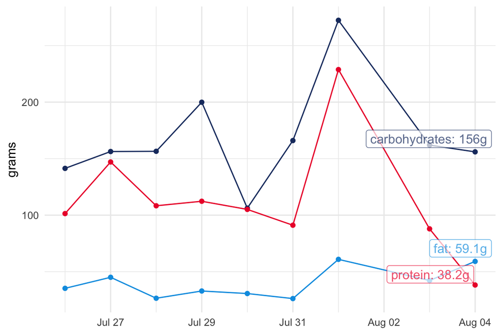

#### Total calories consumed, daily

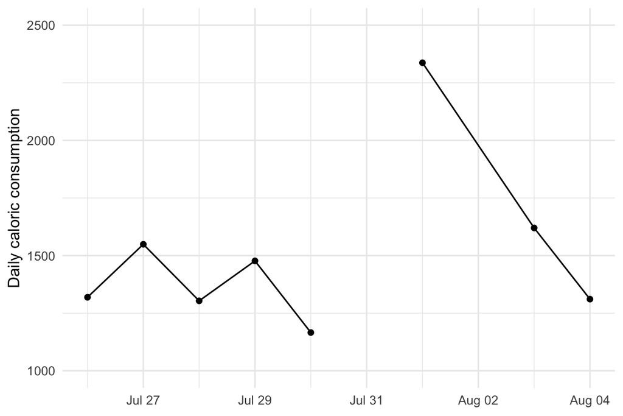

#### Macronutrient breakdown, weekly average

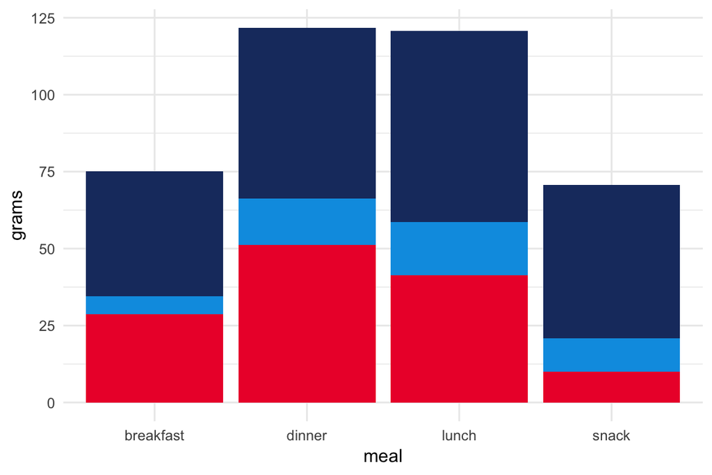

#### Macronutrient breakdown per meal, daily

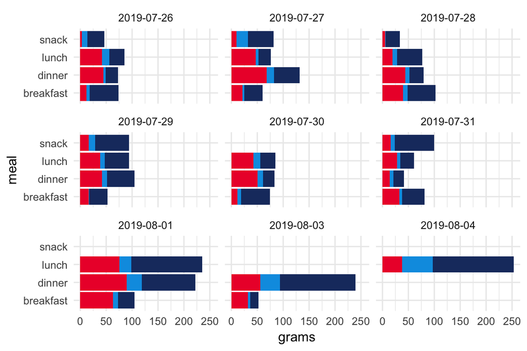